# Getting Started

Alexandra Erdmann

## Introduction

The purpose of this vignette is to explain the use of `getClinicalTrials()`, the core function of this package. `getClinicalTrials()` can be used to simulate a large number of clinical trials with endpoints progression-free survival (PFS) and overall survival (OS). The underlying model is a survival multistate model with an initial state, an intermediate `progression` state and an absorbing `death` state. The multistate model approach has the advantage of naturally accounting for the correlation between the PFS and OS endpoints (Meller et al. 2019). OS is defined as the time to reach the absorbing state death and PFS is defined as the time to reach the absorbing state `death` or the intermediate state `progression`, whichever occurs first. Figure 1 shows the multistate model with the corresponding transition hazards. To get started quickly, we show a simple and quick example of a clinical trial simulation.

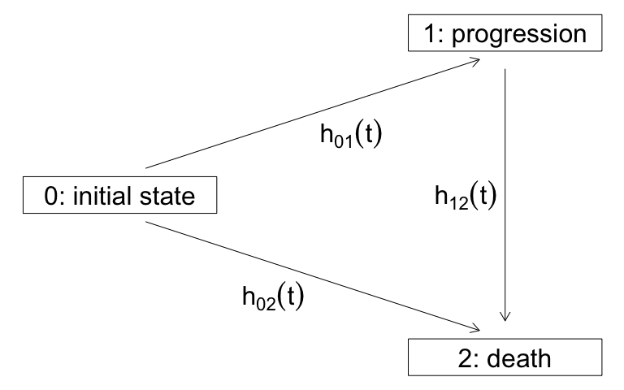

Figure 1 - Multistate model with indermediate state progession and absorbing state death

## Simulation Specifications

`getClinicalTrials()` simulates trials with an arbitrary number of treatment arms. In general, the argument specifications were tried to be similar to the R-package Rpact (Wassmer and Pahlke 2021) in order to be more user-friendly. For illustration, we consider a trial with two arms. The number of patients per trial must be specified. In our example simulation there are 30 patients in the first treatment arm and 60 in the second treatment arm:

```r
nPat <- c(30, 60)
```

The transition parameters describing the transition hazards per treatment arm must be passed as a list to `getClinicalTrials()`. The class `TransitionParameters` contains the elements `hazards`, `intervals`, `weibull_rates` and `family` which allow to describe transition hazards leading to exponential, piecewise exponential or Weibull distributed survival times. There are some helper functions in the `simIDM` package to create the appropriate transition parameters for the desired distribution. - `exponential_transition()`: creates a list with class `TransitionParameters` containing hazards, time intervals and Weibull rates for exponential event times in an illness-death model. - `piecewise_exponential()`: creates a list with class `TransitionParameters` containing hazards, time intervals and Weibull rates for piecewise exponential event times in an illness-death model. - `weibull_transition()`: creates a list with class `TransitionParameters` containing hazards, time intervals and Weibull rates for Weibull distributed event times in an illness-death model.

In our example we consider constant hazard rates, i.e. exponential distributed event times.

```r
library(simIDM)

transitionGroup1 <- exponential_transition(h01 = 1.2, h02 = 1.5, h12 = 1.6)
print(transitionGroup1$hazards)
```

```
#> $h01
#> [1] 1.2
#>
#> $h02
#> [1] 1.5
#>
#> $h12
#> [1] 1.6
```

```r
transitionGroup2 <- exponential_transition(h01 = 1, h02 = 1.3, h12 = 1.7)
print(transitionGroup2$hazards)
```

```
#> $h01
#> [1] 1
#>
#> $h02
#> [1] 1.3
#>
#> $h12
#> [1] 1.7
```

```r
transitionbyArm <- list(transitionGroup1, transitionGroup2)
```

The specification for random patient dropouts can be passed directly to `getClinicalTrials()`. A list with elements `rate` and `time` specifies the drop-out probability. Random censoring times are generated using the exponential distribution. `dropout$rate` specifies the drop-out probability per `dropout$time` time units. The dropout parameters can be specified either as one list that should be applied to all treatment groups or a separate list for each treatment group. If `dropout$rate` is equal to 0, then no censoring due to dropout is applied. In our example we expect that 10% of the patients drop-out within 12 months per treatment group (we take month as the time unit of our trial), thus we specify:

```r
dropout <- list(rate = 0.1, time = 12)
```

There are two time-scales that we need to consider when simulating multistate data. The individual time scale with start in the initial state at time 0 and the study time scale, which matches the individual time scale only if the study start time (e.g. randomization date) is the same time in calendar time for all patients. It can also be specified that patients enter the study in a staggered manner. Uniformly distributed random variables are used to generate staggered study entry times. There are two possibilities for the specification: Either, the length of the accrual period is specified, e.g. 12 month, in which case the staggered entry times are generated in each treatment group using random variables $U ~Unif(0, 12)$. Or, it is specified how many patients are recruited per time unit in each treatment group. Thus, if 10 patients are recruited per month, then the staggered entry times are generated using random variables $U ~Unif(0, 30/10)$. A list `accrual` with elements `accrualParam` and `accrualValue` is passed to `getClinicalTrials()` describing the accrual intensity. For `accrualParam` equal time, `accrualValue`describes the length of the accrual period. For `accrualParam` equal intensity, it describes the number of patients recruited per time unit. If `accrualValue` is equal to 0, all patients start at the same calender time in the initial state. The accrual parameters can be specified either as one list that should be applied to all treatment groups or a separate list for each treatment group.

```r
# first example
accrual <- list(param = "intensity", value = 12)
# second example
accrual <- list(param = "intensity", value = 3)
```

## Application

We now simulate 100 (`nRep`=100) clinical trials with the parameters described and specified above. There are two options for how the output data is presented, one row per patient or one row per transition and patient. Let’s take a look at both.

```r
simStudies1 <- getClinicalTrials(
  nRep = 100, nPat = nPat, seed = 1234, datType = "1rowTransition",
  transitionByArm = transitionbyArm, dropout = dropout,
  accrual = accrual
)
```

[output not shown]

```r
simStudies2 <- getClinicalTrials(
  nRep = 100, nPat = nPat, seed = 1234, datType = "1rowPatient",
  transitionByArm = transitionbyArm, dropout = dropout,
  accrual = accrual
)
```

[output not shown]

## Output Data

We get as output a list with `nRep` elements, each containing a data set of a single simulated trial. The specification of the seed ensures, that the the datasets of the two lists contain the same study data, only the presentation is different. `simStudies1` shows the transition times per patient and `simStudies2` the PFS and OS times per patient.

```r
head(simStudies1[[1]], 6)
```

```
#>   id from to     entry       exit entryAct   exitAct    censAct trt
#> 1  1    0  2 0.0000000 0.46787743 1.234711  1.702588 286.171654   1
#> 2  2    0  2 0.0000000 0.26010392 7.971605  8.231709  36.076123   1
#> 3  3    0  2 0.0000000 0.06150124 7.442772  7.504273   8.192422   1
#> 4  4    0  1 0.0000000 0.25964639 9.159742  9.419389 207.649214   1
#> 5  4    1  2 0.2596464 2.13580247 9.419389 11.295545 207.649214   1
#> 6  5    0  2 0.0000000 0.25227459 9.945982 10.198257  54.044011   1
```

```r
head(simStudies2[[1]], 5)
```

```
#>   id trt    PFStime CensoredPFS PFSevent     OStime CensoredOS OSevent
#> 1  1   1 0.46787743           0        1 0.46787743          0       1
#> 2  2   1 0.26010392           0        1 0.26010392          0       1
#> 3  3   1 0.06150124           0        1 0.06150124          0       1
#> 4  4   1 0.25964639           0        1 2.13580247          0       1
#> 5  5   1 0.25227459           0        1 0.25227459          0       1
#>   recruitTime OStimeCal PFStimeCal
#> 1    1.234711  1.702588   1.702588
#> 2    7.971605  8.231709   8.231709
#> 3    7.442772  7.504273   7.504273
#> 4    9.159742 11.295545   9.419389
#> 5    9.945982 10.198257  10.198257
```

If we want to simulate only one trial, `getOneClinicalTrial` can also be used and with `getDatasetWideFormat` can be used to convert the dataset from being displayed with transition time to displaying PFS and OS times.

```r
simStudy_Trans <- getOneClinicalTrial(
  nPat = nPat, transitionByArm = transitionbyArm,
  dropout = dropout,
  accrual = accrual
)

simStudy_PFSOS <- getDatasetWideFormat(simStudy_Trans)
head(simStudy_Trans, 10)
```

```
#>    id from to     entry       exit entryAct  exitAct   censAct trt
#> 1   1    0  2 0.0000000 0.32181077 5.063864 5.385675 335.59100   1
#> 2   2    0  1 0.0000000 0.44263317 8.083607 8.526241  96.83774   1
#> 3   2    1  2 0.4426332 0.70429214 8.526241 8.787899  96.83774   1
#> 4   3    0  2 0.0000000 0.03497509 4.478954 4.513929  74.19954   1
#> 5   4    0  1 0.0000000 0.19827637 5.606922 5.805199  48.06033   1
#> 6   4    1  2 0.1982764 0.93065829 5.805199 6.537580  48.06033   1
#> 7   5    0  2 0.0000000 0.06933912 9.077324 9.146663 119.07514   1
#> 8   6    0  1 0.0000000 0.44623034 8.790901 9.237131  81.78121   1
#> 9   6    1  2 0.4462303 0.44837021 9.237131 9.239271  81.78121   1
#> 10  7    0  1 0.0000000 0.63135991 8.441810 9.073170  97.36028   1
```

```r
head(simStudy_PFSOS, 10)
```

```
#>    id trt    PFStime CensoredPFS PFSevent     OStime CensoredOS OSevent
#> 1   1   1 0.32181077           0        1 0.32181077          0       1
#> 2   2   1 0.44263317           0        1 0.70429214          0       1
#> 3   3   1 0.03497509           0        1 0.03497509          0       1
#> 4   4   1 0.19827637           0        1 0.93065829          0       1
#> 5   5   1 0.06933912           0        1 0.06933912          0       1
#> 6   6   1 0.44623034           0        1 0.44837021          0       1
#> 7   7   1 0.63135991           0        1 1.69430412          0       1
#> 8   8   1 1.60671207           0        1 1.60671207          0       1
#> 9   9   1 0.22975563           0        1 0.50776145          0       1
#> 10 10   1 0.06312064           0        1 0.06312064          0       1
#>    recruitTime OStimeCal PFStimeCal
#> 1    5.0638640  5.385675   5.385675
#> 2    8.0836073  8.787899   8.526241
#> 3    4.4789541  4.513929   4.513929
#> 4    5.6069222  6.537580   5.805199
#> 5    9.0773241  9.146663   9.146663
#> 6    8.7909011  9.239271   9.237131
#> 7    8.4418100 10.136114   9.073170
#> 8    0.4754946  2.082207   2.082207
#> 9    2.8876069  3.395368   3.117363
#> 10   6.6150703  6.678191   6.678191
```

It is also possible to generate a a study that censors all patients after a pre-specified number of events (PFS or OS) occurred.

```r
simStudy_Trans <- getOneClinicalTrial(
  nPat = nPat, transitionByArm = transitionbyArm,
  dropout = dropout,
  accrual = accrual
)

simStudy_PFSOS <- getDatasetWideFormat(simStudy_Trans)
head(simStudy_Trans, 10)
```

```
#>    id from to      entry       exit    entryAct   exitAct   censAct trt
#> 1   1    0  1 0.00000000 0.06961555 7.780312062 7.8499276 102.95744   1
#> 2   1    1  2 0.06961555 1.04718403 7.849927611 8.8274961 102.95744   1
#> 3   2    0  2 0.00000000 0.26116360 4.626272118 4.8874357  47.17874   1
#> 4   3    0  2 0.00000000 0.15075060 6.508751956 6.6595026 168.99387   1
#> 5   4    0  1 0.00000000 0.56212147 2.690053477 3.2521749  48.75687   1
#> 6   4    1  2 0.56212147 2.41915162 3.252174950 5.1092051  48.75687   1
#> 7   5    0  2 0.00000000 0.01950124 8.332294915 8.3517962 118.78556   1
#> 8   6    0  2 0.00000000 0.47629626 0.024984612 0.5012809 145.10228   1
#> 9   7    0  2 0.00000000 0.64391257 0.003990494 0.6479031  63.08757   1
#> 10  8    0  2 0.00000000 0.56831986 7.120901188 7.6892211 659.17510   1
```

```r
head(simStudy_PFSOS, 10)
```

```
#>    id trt    PFStime CensoredPFS PFSevent     OStime CensoredOS OSevent
#> 1   1   1 0.06961555           0        1 1.04718403          0       1
#> 2   2   1 0.26116360           0        1 0.26116360          0       1
#> 3   3   1 0.15075060           0        1 0.15075060          0       1
#> 4   4   1 0.56212147           0        1 2.41915162          0       1
#> 5   5   1 0.01950124           0        1 0.01950124          0       1
#> 6   6   1 0.47629626           0        1 0.47629626          0       1
#> 7   7   1 0.64391257           0        1 0.64391257          0       1
#> 8   8   1 0.56831986           0        1 0.56831986          0       1
#> 9   9   1 0.27386179           0        1 0.27386179          0       1
#> 10 10   1 0.41250249           0        1 1.15933490          0       1
#>    recruitTime OStimeCal PFStimeCal
#> 1  7.780312062 8.8274961  7.8499276
#> 2  4.626272118 4.8874357  4.8874357
#> 3  6.508751956 6.6595026  6.6595026
#> 4  2.690053477 5.1092051  3.2521749
#> 5  8.332294915 8.3517962  8.3517962
#> 6  0.024984612 0.5012809  0.5012809
#> 7  0.003990494 0.6479031  0.6479031
#> 8  7.120901188 7.6892211  7.6892211
#> 9  5.236761118 5.5106229  5.5106229
#> 10 5.930290024 7.0896249  6.3427925
```

```r
simStudy_40PFS <- censoringByNumberEvents(data = simStudy_PFSOS, eventNum = 40, typeEvent = "PFS")
simStudy_30POS <- censoringByNumberEvents(data = simStudy_PFSOS, eventNum = 30, typeEvent = "PFS")
simStudy_40PFS
```

```
#>    id trt    PFStime PFSevent     OStime CensoredOS OSevent recruitTime
#> 1   2   1 0.26116360        1 0.26116360          0       1 4.626272118
#> 2   3   1 0.15075060        1 0.15075060          0       1 6.508751956
#> 3   4   1 0.56212147        1 2.41915162          0       1 2.690053477
#> 4   6   1 0.47629626        1 0.47629626          0       1 0.024984612
#> 5   7   1 0.64391257        1 0.64391257          0       1 0.003990494
#> 6   9   1 0.27386179        1 0.27386179          0       1 5.236761118
#> 7  10   1 0.41250249        1 0.89799098          1       0 5.930290024
#> 8  12   1 0.62277501        1 0.64594684          0       1 4.695528368
#> 9  13   1 0.12997017        1 0.12997017          0       1 1.509620696
#> 10 14   1 1.04040922        1 1.04040922          0       1 1.242366128
#> 11 15   1 0.02544847        1 0.02544847          0       1 4.443782684
#> 12 17   1 0.57767544        1 0.57767544          0       1 0.823651729
#> 13 18   1 0.09734062        1 0.09734062          0       1 1.893173764
#> 14 19   1 0.16208977        1 0.16208977          0       1 4.184192105
```

[output cut: 71 more lines]

```r
simStudy_30POS
```

```
#>    id trt    PFStime PFSevent     OStime CensoredOS OSevent recruitTime
#> 1   2   1 0.26116360        1 0.26116360          0       1 4.626272118
#> 2   4   1 0.56212147        1 2.41915162          0       1 2.690053477
#> 3   6   1 0.47629626        1 0.47629626          0       1 0.024984612
#> 4   7   1 0.64391257        1 0.64391257          0       1 0.003990494
#> 5   9   1 0.26098435        0 0.26098435          1       0 5.236761118
#> 6  12   1 0.62277501        1 0.64594684          0       1 4.695528368
#> 7  13   1 0.12997017        1 0.12997017          0       1 1.509620696
#> 8  14   1 1.04040922        1 1.04040922          0       1 1.242366128
#> 9  15   1 0.02544847        1 0.02544847          0       1 4.443782684
#> 10 17   1 0.57767544        1 0.57767544          0       1 0.823651729
#> 11 18   1 0.09734062        1 0.09734062          0       1 1.893173764
#> 12 19   1 0.16208977        1 0.16208977          0       1 4.184192105
#> 13 22   1 0.04763364        1 0.04763364          0       1 3.433677910
#> 14 23   1 0.45706380        1 0.45706380          0       1 4.143891723
```

[output cut: 57 more lines]

## References

Meller, Matthias, Jan Beyersmann, and Kaspar Rufibach. 2019. “Joint Modeling of Progression-Free and Overall Survival and Computation of Correlation Measures.” *Statistics in Medicine* 38 (22): 4270–89.

Wassmer, Gernot, and Friedrich Pahlke. 2021. *Rpact: Confirmatory Adaptive Clinical Trial Design and Analysis*. https://CRAN.R-project.org/package=rpact.